# Mestrado em Hemoterapia: Bioestatística

## Teste de Hipóteses: Introdução

## Definindo hipóteses

- Objetivo em muitos estudos: checar se os dados apóiam certas afirmações que são feitas para uma população.
- Afirmações a serem testadas: **hipóteses**.
- Expressamos as hipóteses em termos dos parâmetros da população.
- Por exemplo: o parâmetro pode ser uma proporção populacional.

## Passos de um teste de hipótese

- **Passo 1: suposições.**

O teste é válido sob algumas suposições. A mais importante assume que os dados do experimento foram produzidos através de um processo de aleatorização.

- **Passo 2: hipóteses.**

O teste de hipótese tem sempre duas hipóteses sobre o parâmetro populacional de interesse. As hipóteses devem ser definidas **antes** de se realizar o experimento e coletar dados.

- **Hipótese Nula - \(H_0\):** afirma que o parâmetro populacional assume um dado valor.
- **Hipótese Alternativa - \(H_a\):** afirma que o parâmetro populacional assume outros valores, diferente do valor descrito na \(H_0\).

## Passos de um teste de hipótese

- **Passo 3: estatística do teste.**

Vimos que podemos usar uma estatística para estimar um parâmetro populacional. A **estatística do teste** descreve quão longe do parâmetro populacional usado na \(H_0\) a estimativa está.

> Por exemplo, se \(H_0:\) \(p=1/3\), e se \(\hat{p}=40/116=0.345\), queremos uma estatística que quantifique quão longe está \(\hat{p}=0.345\) de \(p=1/3\).
- **Passo 4: valor-de-p.**

Para interpretar uma estatística do teste, vamos usar uma probabilidade para resumir a evidência contra \(H_0\). Esta probabilidade é o que chamamos de **valor-de-p**.

## Passos de um teste de hipótese

- **Passo 5: conclusão.**

Baseado no valor-de-p, decidir se rejeita ou não a hipótese nula. Note que a conclusão é sempre em termos da hipótese nula: rejeitar ou não \(H_0\).

Mas quão pequeno deve ser o valor-de-p para ser considerado forte evidência contra \(H_0\)?

Geralmente, fixamos o **nível de significância** do teste (\(\alpha\)), e usamos a seguinte regra. É comum usarmos \(\alpha=0.05\).

- Se valor-de-p \(\leq \alpha\): rejeitamos \(H_0\), ou seja, os dados trazem forte evidência contra a hipóstese nula
- Se valor-de-p > \(\alpha\): não rejeitamos \(H_0\), ou seja, não temos evidência nos dados contra a hipótese nula

## Passos de um teste de hipótese

> Assumimos primeiro que \(H_0\) é verdadeira.

> Consideramos então todos os valores possíveis para a estatística do teste, de acordo com sua distribuição amostral.

> Calculamos a estatística do teste observada para o experimento realizado e verificamos onde, na distribuição amostral, ela se posiciona.

> Calculamos a probabilidade de um valor igual ou mais extremo ao da estatística do teste observada (valor-de-p). Mais extremo: mais evidência contra \(H_0\).

> Se o valor-de-p obtido é bem pequeno, por exemplo, \(0.01\), isto quer dizer que se \(H_0\) é verdadeira, então seria incomum obter uma amostra com os resultados como o observado. Um valor-de-p muito baixo traz fortes evidências contra \(H_0\).

## Resumo: Teste de Hipótese para uma proporção

Suponho que temos uma população e uma hipótese sobre a proporção \(p\) de indíviduos com certa característica.

**Hipóteses:**  
\[ \begin{aligned} H_0: p = p_0 \quad \mbox{vs} \quad H_a: & p \neq p_0 \mbox{ (bilateral)} \\ & p < p_0 \mbox{ (unilateral à esquerda)} \\ & p > p_0 \mbox{ (unilateral à direita)} \end{aligned} \]

**Estatística do teste:** Baseada na distribuição amostral de \(\hat p\) \[Z=\frac{\hat{p}-p_0}{\sqrt{\frac{p_0(1-p_0)}{n}}} \overset{H_0}{\sim} N(0,1)\]

**Condição:** \(np_0 ≥ 10\) e \(n(1−p_0) ≥ 10\) para aproximação normal

## Resumo: Teste de Hipótese para uma proporção

**valor-de-p**

- \(H_a: p \neq p_0\) (bilateral): valor-de-p=\(P(|Z| ≥|z_{obs}|)\)
- \(H_a: p < p_0\) (unilateral à esquerda): valor-de-p=\(P(Z \leq z_{obs})\)
- \(H_a: p > p_0\) (unilateral à direita): valor-de-p=\(P(Z \geq z_{obs})\)

**Conclusão**

Para um nível de significância \(\alpha\):

- Se valor-de-p \(\leq \alpha\): rejeitamos \(H_0\)
- Se valor-de-p > \(\alpha\): não rejeitamos \(H_0\)

## Exemplo

Uma indústria farmacêutica diz que menos de 20% dos pacientes que estão usando um certo medicamento terão efeitos colaterais.

Realizou-se então um ensaio clínico com 400 pacientes e verificou-se que 68 pacientes apresentaram efeitos colaterais

**Hipóteses:** \(H_0: p = 0.20 \quad \mbox{vs} \quad H_a: p < 0.20\)

**Estatística do teste:** Da amostra temos que \(\hat p = 68/400 = 0.17\) \[z_{obs} = \frac{\hat p - p_0}{\sqrt{\frac{p_0(1-p_0)}{n}}} = \frac{0.17 - 0.20}{\sqrt{\frac{0.20(1-0.20)}{400}}} = -1.5\]

## Exemplo (continuação)

\[\mbox{valor-de-p} =P(Z \leq- 1.5) = 0.067\]

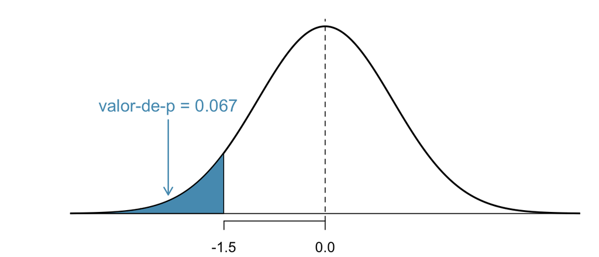

**Conclusão**: Para \(\alpha=0.05\), como o valor-de-p é maior que 0.05, não temos evidências nos dados para rejeitar a hipótese de que \(p=0.20\). Na verdade, a evidência está na direção que a indústria farmacêutica queria, mas não é o suficiente para rejeitar \(H_0\).

## Exemplo (continuação)

E se estivéssemos testando: \(H_0: p = 0.20 \quad \mbox{vs} \quad H_a: p \neq 0.20\)

\[\begin{aligned} \mbox{valor-de-p} &=P(|Z| \geq 1.5) = P(Z \leq -1.5) + P(Z \geq 1.5) \\ &= 2P(Z \leq -1.5) = 2 \times 0.067=0.134 \end{aligned} \]

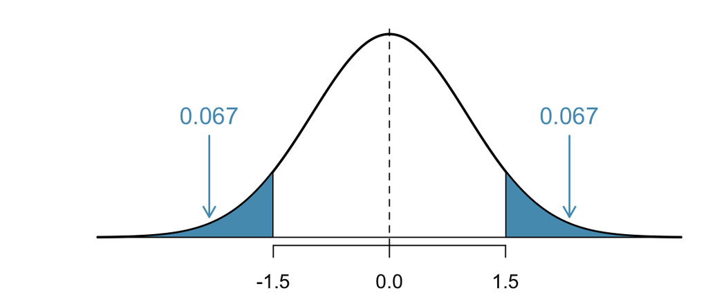

**Conclusão**: Para \(\alpha=0.05\), como o valor-de-p é maior que 0.05, não temos evidências nos dados para rejeitar a hipótese de que \(p=0.20\).

## Coca vs Coca Zero - você consegue distinguir?

[figure not shown]

## Experimento da Coca vs Coca Zero

Algumas pessoas afirmam que conseguem distinguir o sabor da coca-cola normal da coca zero.

> Faremos então um teste para comprovar se a afirmação é verdadeira.

> Experimento:
- Sorteia-se, sem a pessoa saber, coca ou coca zero, usando um dado (se sair par, recebe uma coca-cola normal, se sair ímpar, uma coca zero.
- A bebida sorteada é então dada à pessoa sendo testada, que deve então dizer qual ela acredita que é.
- Repetimos isso 20 vezes.
- Anota-se o total de acertos.

## Experimento da Coca vs Coca Zero

**Suposições:**

- Cada tentativa, \(X_i\), é uma Bernoulli\((p)\), em que \(p\) é a probabilidade de acerto.
- Estamos interessados no total de acertos em 20 tentativas: \(T=\sum_{i=1}^{20}X_i\sim\mbox{Binomial}(20,p)\).
- Podemos usar a aproximação pela Normal caso as condições sejam satisfeitas.

> **Hipóteses:**
- \(H_0: p=1/2\), indicando que a pessoa não consegue diferenciar as duas bebidas
- \(H_a: p>1/2\).

## Experimento da Coca vs Coca Zero

> **Estatística do teste:**
- Usamos \(T=\sum_{i=1}^{20}X_i\sim\mbox{Binomial}(20,p)\).

> **Valor-de-p:**
- Evidência contra \(H_0\). Calculamos a probabilidade, sob \(H_0\), de ocorrer um valor igual ou mais extremo ao valor observado no experimento.

## Experimento da Coca vs Coca Zero

**Resultado do experimento:**

> Seja \(t_{obs}=19\) o número de acertos, o valor-de-p foi então: \(P(T\geq 19)=0\), onde \(T\overset{H_0}{\sim}\mbox{Binomial}(20,1/2)\).

> **Conclusão:** Decidimos rejeitar \(H_0\).

## Experimento da Coca vs Coca Zero

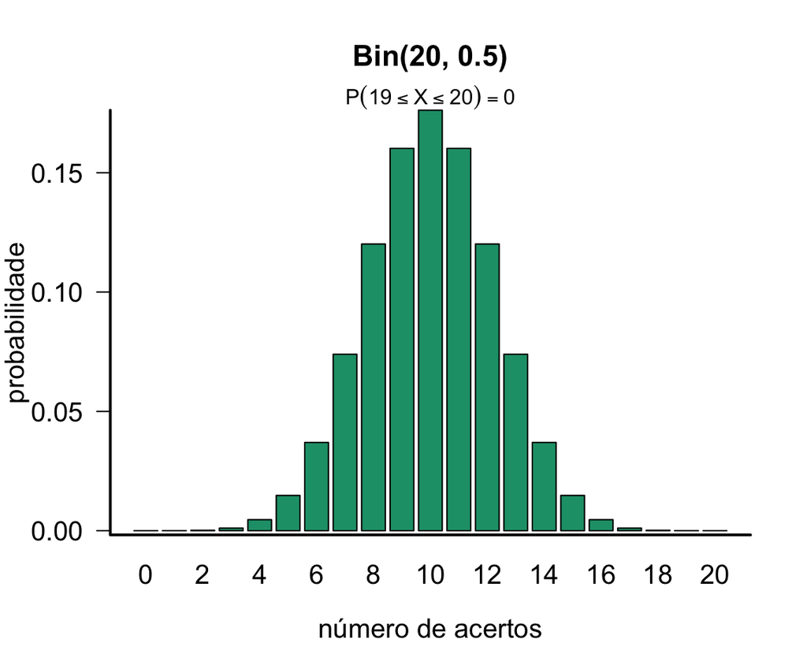

## Experimento da Coca vs Coca Zero

Utilizando a aproximação pela Normal:

> Temos que \(T \sim Bin(20, p)\), onde \(T\) é o número de acertos.

> A proporção amostral de acertos \(\hat p = \frac{T}{20}= 19/20=0.95\).

> Vamos testar o seguinte: \(H_0: p = 0.50 \quad \mbox{vs} \quad H_a: p > 0.50\).

> **Estatística do teste:**

\[z_{obs} = \frac{\hat p - p_0}{\sqrt{\frac{p_0(1-p_0)}{n}}} = \frac{0.95 - 0.5}{\sqrt{\frac{(0.50)(0.50)}{20}}} = 4.02\]

**valor-de-p** = \(P(Z \geq 4.02) = 0\)

**Conclusão:** Fixando \(\alpha=0.05\), rejeitamos a hipótese de que \(p=0.5\) e, portanto, rejeitamos a hipótese de que probabilidade de acertos é 50%.

## Experimento da Coca vs Coca Zero

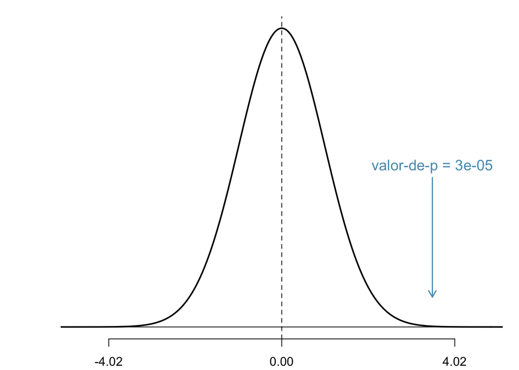

## Leituras

- [Ross](http://www.sciencedirect.com/science/article/pii/B9780123743886000090): capítulo 9.
- [OpenIntro](https://www.openintro.org/stat/textbook.php): seções 4.3 e 6.1.

Slides produzidos pelos professores:

- Samara Kiihl
- Tatiana Benaglia
- Benilton Carvalho
- Rafael Maia